# Why Biostatistics Matters

The Clinician’s Statistical Toolkit

## Learning Objectives

1. Explain why statistical literacy is essential for clinical practice
2. Distinguish between qualitative (categorical) and quantitative (numerical) data
3. Classify variables using **NOIR**: Nominal, Ordinal, Interval, Ratio
4. Choose appropriate statistics based on measurement scale
5. Distinguish descriptive from inferential statistics
6. Identify independent and dependent variables
7. Recognise how statistical errors cause real patient harm

## Clinical Hook: The CAST Trial

**The Deadly Assumption (1980s)**

- Post-MI patients have PVCs
- PVCs predict sudden cardiac death
- **Assumption:** suppress PVCs → reduce mortality

**The CAST Result (1989)**

- Antiarrhythmics **doubled** mortality (RR = 2.5)
- Trial stopped early
- Estimated **tens of thousands** of excess deaths per year in the US alone

**Surrogate Endpoint Fallacy**

Suppressing a risk marker is not the same as preventing the disease. The marker (PVCs) was treated instead of the patient.

## More Examples of Statistics Gone Wrong

| Case | What happened | Module |
| --- | --- | --- |
| **HRT** | Observational studies said it prevented heart disease. RCT (WHI) showed it caused it. | 6, 14 |
| **Hydroxychloroquine** | Preliminary data drove global prescribing. RCTs showed no benefit. | 8 |
| **Vioxx** | Cardiovascular risk hidden in subgroup analyses. Withdrawn after ~88,000 excess MI. | 14 |

> **As a clinician, you will read research every week. This course gives you the tools to read it critically.**

## What Is Biostatistics?

Three practical functions for clinicians:

### Summarise

When you look at lab reports over time or compare ward outcomes — that’s **descriptive statistics**.

### Conclude

A BP of 142/90 in one reading doesn’t confirm HTN. A p = 0.04 doesn’t prove a drug works. Statistics handles **uncertainty**.

### Evaluate

Understanding study design, bias, and analysis lets you separate **reliable evidence from noise**.

## Data Types in Medicine

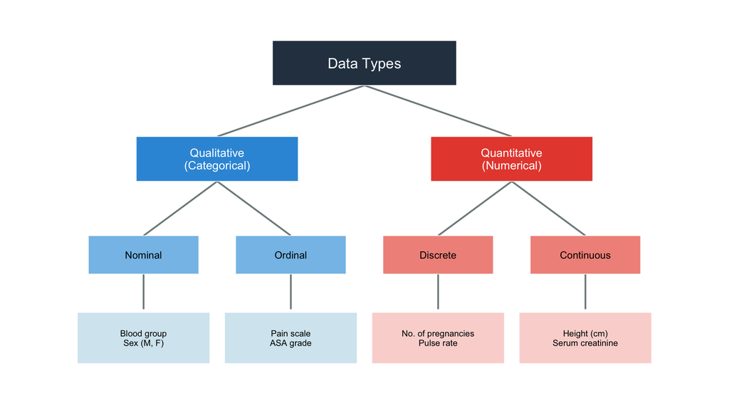

Figure 1

## The NOIR Classification

**Stevens’ Four Levels of Measurement**

| Scale | Order? | Equal intervals? | True zero? | Example |
| --- | --- | --- | --- | --- |
| **N**ominal | No | No | No | Blood group, Sex |
| **O**rdinal | Yes | No | No | NYHA class, GCS |
| **I**nterval | Yes | Yes | No | Temperature (°C) |
| **R**atio | Yes | Yes | Yes | Height, Weight, BP |

**The Ratio Test**

Can you meaningfully say “twice as much”? If yes → **Ratio**. If no → **Interval** or lower.

- “14 g/dL Hb is twice 7 g/dL” ✓ → Ratio
- “40°C is twice as hot as 20°C” ✗ → Interval

## NOIR: Permissible Operations

[figure not shown]

Figure 2

## Choosing the Right Statistics

| Scale | Central Tendency | Spread | Tests |
| --- | --- | --- | --- |
| Nominal | Mode | Frequency | Chi-square, Fisher |
| Ordinal | Median | IQR | Mann-Whitney, Spearman |
| Interval | Mean, Median | SD, IQR | t-test, ANOVA, Pearson |
| Ratio | Mean, Geo. mean | SD, CV | All parametric tests |

**Common Mistake**

Computing the **mean** of NYHA class or Likert scale data. These are ordinal — use the **median** and non-parametric tests.

## Descriptive vs Inferential Statistics

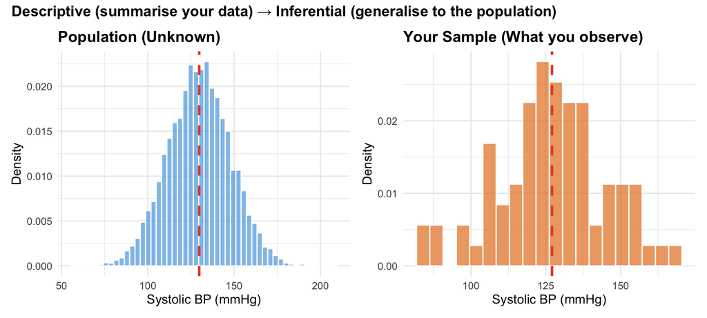

Figure 3

## The Research-to-Bedside Pipeline

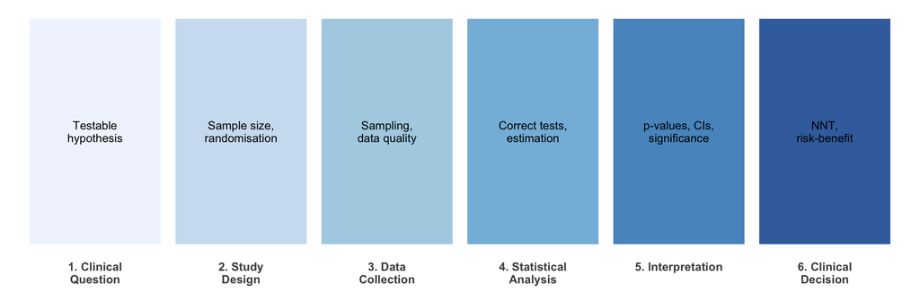

Figure 4

## Variables and Their Roles

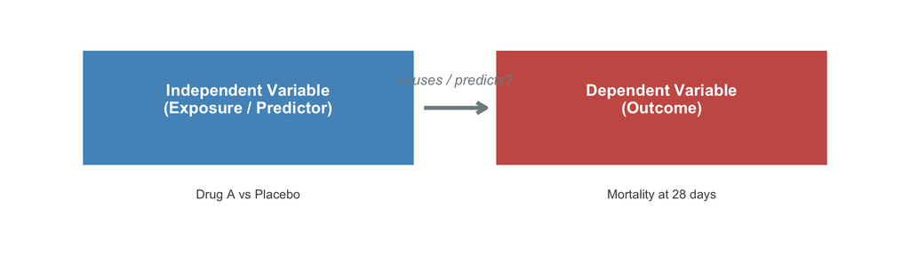

Figure 5

**Confounders**

A **confounder** is associated with both exposure and outcome, distorting the apparent relationship. Coffee → Lung cancer? No — **smoking** is the confounder.

## Key Takeaways

1. **Statistics is not optional** — flawed reasoning has killed patients (CAST, HRT, HCQ)
2. **NOIR classification** determines which statistics and tests are valid
3. **Interval ≠ Ratio** — the “true zero” test (Temperature °C vs Height cm)
4. **Descriptive → Inferential** — from “what I see” to “what is true”
5. **Independent → Dependent** — beware of confounders

## Further Learning

**Videos:**

- [StatQuest: Statistics Fundamentals](https://www.youtube.com/playlist?list=PLblh5JKOoLUK0FLuzwntyYI10UQFUhsY9)
- [Zedstatistics: What is Statistics?](https://www.youtube.com/watch?v=hjZJIVWHnPE)
- [Types of Data: NOIR](https://www.youtube.com/watch?v=hZxnzfnt5v8) — Scribbr

**Books:**

- Bland M. *An Introduction to Medical Statistics*. Ch 1–2.
- Indrayan A. *Medical Biostatistics*. 4th ed. (Indian examples)